# Final_Project

Bryan Z

2023-11-25

## 0.1 Introduction

James is a junior data analyst working in the sustainability analyst team at Clarkston Consulting, a consulting company in Rio, Brazil. Moreno (director of his floor) requests a forecast report on the Renewable Internal Freshwater Resources of Brazil for the next 10 years.

James is sent to Morticia for the data he will use. Then, he is provided a dataset titled: “Renewable internal freshwater resources per capita (cubic meters)” from the website “Our World in Data”. He is left with a forecast report but not with the variables he could use to produce it.

After doing some research, he finds out that renewable internal freshwater resources (cubic meters) is the internal renewable resources in the country, such as internal river flows and groundwater from rainfall. Besides, he realizes that accounting for this is important for assessing a region’s water security, for sustainable agriculture practices or for early detection of drought conditions since climate change is all over the news nowadays.

James realizes that he should not consider population count for this report since the company requesting the consulting service does not need the forecast based on the population but rather on the consumption on water withdrawals from industrial and agricultural processes.

In order to conduct the forecast, James needs to do some feature engineering for the dataset provided by Morticia. He goes ahead and gets the worldwide population data from the World Bank in order to obtaining the Renewable Internal Freshwater Resources of Brazil without counting capita. Based on the initial dataset, he filters the now ready Renewable Internal Freshwater Resources of Brazil for the years 1989 to 2019 since these are the years stored for Brazil in the dataset provided.

### 0.1.1 Feature Engineering for Renewable Internal Freshwater Resources (cubic meters)

```
## Plot variable not specified, automatically selected `.vars =
## Renewable.internal.freshwater.resources..cubic.meters`
```

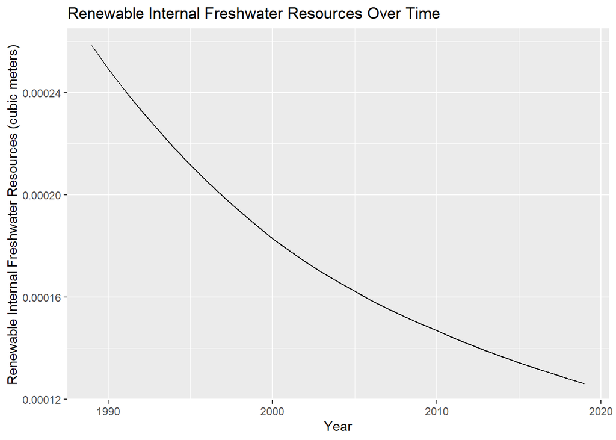

```
## # A tsibble: 31 x 2 [1Y]
##     Year Renewable.internal.freshwater.resources..cubic.meters
##    <int>                                                 <dbl>
##  1  1989                                              0.000258
##  2  1990                                              0.000249
##  3  1991                                              0.000241
##  4  1992                                              0.000233
##  5  1993                                              0.000226
##  6  1994                                              0.000218
##  7  1995                                              0.000212
##  8  1996                                              0.000205
##  9  1997                                              0.000199
## 10  1998                                              0.000194
## # ℹ 21 more rows
```

James quickly realizes that the renewable internal freshwater resources of Brazil have been declining over the years, especially since 1989 these resources had a value of 0.0002584340 cubic meters and for 2019 the number shrunk to 0.0001262151 cubic meters. This reflects an annual percentage decrease of 2.36 %.

To continue, James realizes that two of the time series he will explore for the forecast report will be “Number of Cattle” and “Annual freshwater withdrawals” since these time series align with the requirements.

The “Number of Cattle” dataset was extracted from “Our World in Data” and it indicates the number of animals of the species present in the country at the time of enumeration. It includes animals raised either for draft purposes or for meat, eggs and dairy production or kept for breeding.

### 0.1.2 Annual Cattle Number

```
## Plot variable not specified, automatically selected `.vars =
## Cattle...00000866....Stocks...005111....animals`
```

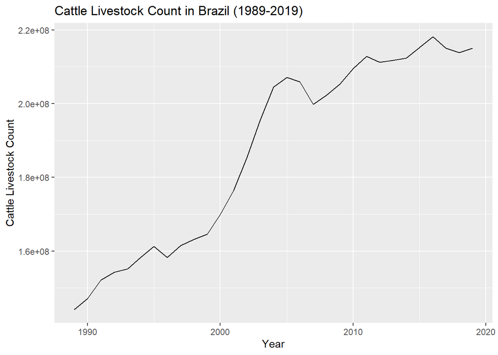

```
## # A tsibble: 31 x 2 [1Y]
##     Year Cattle...00000866....Stocks...005111....animals
##    <int>                                           <int>
##  1  1989                                       144154096
##  2  1990                                       147102320
##  3  1991                                       152135504
##  4  1992                                       154229296
##  5  1993                                       155134080
##  6  1994                                       158243232
##  7  1995                                       161227936
##  8  1996                                       158288544
##  9  1997                                       161416160
## 10  1998                                       163154352
## # ℹ 21 more rows
```

James reflects on the increasing cattle number in Brazil since 1989 to 2019. In 1989 the cattle count was 144154096 and for 2019 it counted for 215008960, meaning an annual percentage increase of 1.34 %.

The other time series,“Annual freshwater withdrawals”, refers to total water withdrawals. It also includes water from desalination plants, agriculture (irrigation and livestock production), industry (cooling thermoelectric plants) and domestic uses (drinking water, municipal use or supply, use for public services, commercial establishments, and homes).

### 0.1.3 Annual Freshwater Withdrawals

```
## Plot variable not specified, automatically selected `.vars =
## Annual.freshwater.withdrawals..total..billion.cubic.meters.`
```

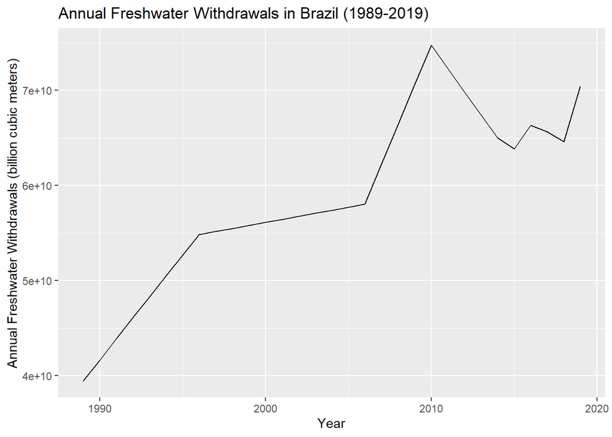

```
## # A tsibble: 31 x 2 [1Y]
##     Year Annual.freshwater.withdrawals..total..billion.cubic.meters.
##    <int>                                                       <dbl>
##  1  1989                                                 39446667000
##  2  1990                                                 41650000000
##  3  1991                                                 43853333000
##  4  1992                                                 46056667000
##  5  1993                                                 48260000000
##  6  1994                                                 50463333000
##  7  1995                                                 52666668000
##  8  1996                                                 54830000000
##  9  1997                                                 55150000000
## 10  1998                                                 55470000000
## # ℹ 21 more rows
```

James reflects on the increasing freshwater withdrawals in Brazil since 1989 to 2019. In 1989 the water withdrawal was 39446667000 cubic meters and for 2019 it was 70430000000 cubic meters, meaning an annual percentage increase of 1.95 %.

Down below, the dataset that James creates with all the time series for his forecast report on the Renewable Internal Freshwater Resources of Brazil for the next 10 years.

## 0.2 Joining Variables

```
## # A tsibble: 31 x 4 [1Y]
##     Year Renewable.internal.fres…¹ Cattle...00000866...…² Annual.freshwater.wi…³
##    <int>                     <dbl>                  <int>                  <dbl>
##  1  1989                  0.000258              144154096            39446667000
##  2  1990                  0.000249              147102320            41650000000
##  3  1991                  0.000241              152135504            43853333000
##  4  1992                  0.000233              154229296            46056667000
##  5  1993                  0.000226              155134080            48260000000
##  6  1994                  0.000218              158243232            50463333000
##  7  1995                  0.000212              161227936            52666668000
##  8  1996                  0.000205              158288544            54830000000
##  9  1997                  0.000199              161416160            55150000000
## 10  1998                  0.000194              163154352            55470000000
## # ℹ 21 more rows
## # ℹ abbreviated names: ¹Renewable.internal.freshwater.resources..cubic.meters,
## #   ²Cattle...00000866....Stocks...005111....animals,
## #   ³Annual.freshwater.withdrawals..total..billion.cubic.meters.
```

Once being ready, James decides on using Dynamic Regression with ARIMA Errors for his forecast report.

## 0.3 Dynamic Regression

#### 0.3.0.1 Stationarity

```
##
## #######################
## # KPSS Unit Root Test #
## #######################
##
## Test is of type: mu with 2 lags.
##
## Value of test-statistic is: 0.9723
##
## Critical value for a significance level of:
##                 10pct  5pct 2.5pct  1pct
## critical values 0.347 0.463  0.574 0.739
```

```
##
## #######################
## # KPSS Unit Root Test #
## #######################
##
## Test is of type: mu with 2 lags.
##
## Value of test-statistic is: 0.045
##
## Critical value for a significance level of:
##                 10pct  5pct 2.5pct  1pct
## critical values 0.347 0.463  0.574 0.739
```

```
##
## #######################
## # KPSS Unit Root Test #
## #######################
##
## Test is of type: mu with 2 lags.
##
## Value of test-statistic is: 0.1532
##
## Critical value for a significance level of:
##                 10pct  5pct 2.5pct  1pct
## critical values 0.347 0.463  0.574 0.739
```

Once again, the test statistic (0.1532) is less than the critical values at all significance levels. Thus, he fails to reject the null hypothesis suggesting that the time series for Annual Freshwater Withdrawals is stationary.

Now, it is time for James to fit the models and create forecasts for the future 10 years.

#### 0.3.0.2 Model #1

```
## Series: Renewable.internal.freshwater.resources..cubic.meters
## Model: LM w/ ARIMA(0,0,0) errors
##
## Coefficients:
##       Cattle...00000866....Stocks...005111....animals  intercept
##                                                 0e+00      4e-04
## s.e.                                            2e-04      2e-04
##
## sigma^2 estimated as 1.164e-10:  log likelihood=311.6
## AIC=-617.2   AICc=-616.31   BIC=-612.89
```

James modeled the time series “Renewable.internal.freshwater.resources..cubic.meters” using an ARIMA model with an external regressor, specifically the variable “Cattle…00000866….Stocks…005111….animals.” The ARIMA component of the model was specified as ARIMA(0,0,0).

James, then, proceeded to evaluate the residuals as follows to provide insights into the model’s performance.

```
## Plot variable not specified, automatically selected `.vars =
## Renewable.internal.freshwater.resources..cubic.meters`
```

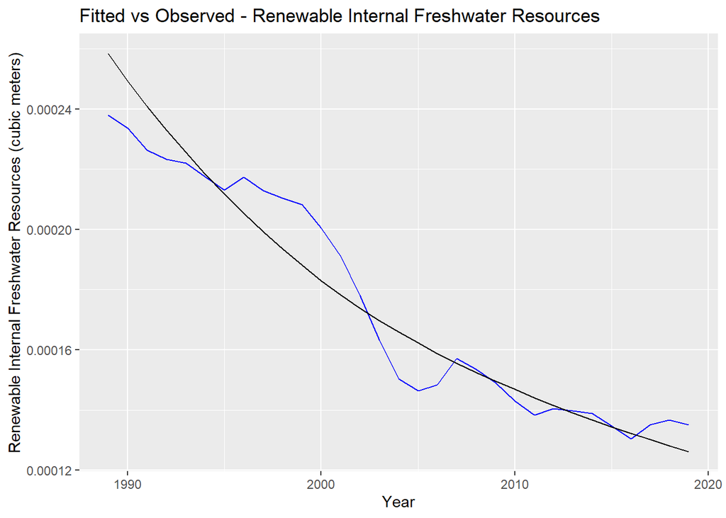

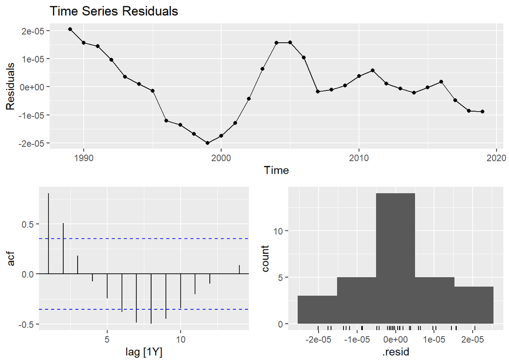

```
## # A tibble: 1 × 3
##   .model                                                       lb_stat lb_pvalue
##   <chr>                                                          <dbl>     <dbl>
## 1 "ARIMA(Renewable.internal.freshwater.resources..cubic.meter…    79.9  3.00e-11
```

```
## # A tsibble: 31 x 6 [1Y]
## # Key:       .model [1]
##    .model                  Year Renewable.internal.f…¹ .fitted   .resid   .innov
##    <chr>                  <int>                  <dbl>   <dbl>    <dbl>    <dbl>
##  1 "ARIMA(Renewable.inte…  1989               0.000258 2.38e-4  2.06e-5  2.06e-5
##  2 "ARIMA(Renewable.inte…  1990               0.000249 2.34e-4  1.57e-5  1.57e-5
##  3 "ARIMA(Renewable.inte…  1991               0.000241 2.26e-4  1.45e-5  1.45e-5
##  4 "ARIMA(Renewable.inte…  1992               0.000233 2.23e-4  9.66e-6  9.66e-6
##  5 "ARIMA(Renewable.inte…  1993               0.000226 2.22e-4  3.57e-6  3.57e-6
##  6 "ARIMA(Renewable.inte…  1994               0.000218 2.17e-4  1.02e-6  1.02e-6
##  7 "ARIMA(Renewable.inte…  1995               0.000212 2.13e-4 -1.37e-6 -1.37e-6
##  8 "ARIMA(Renewable.inte…  1996               0.000205 2.17e-4 -1.20e-5 -1.20e-5
##  9 "ARIMA(Renewable.inte…  1997               0.000199 2.13e-4 -1.35e-5 -1.35e-5
## 10 "ARIMA(Renewable.inte…  1998               0.000194 2.10e-4 -1.68e-5 -1.68e-5
## # ℹ 21 more rows
## # ℹ abbreviated name: ¹Renewable.internal.freshwater.resources..cubic.meters
```

##### 0.3.0.2.1 10-Year Projection for Renewable Internal Freshwater Resources based on Cattle Numbers

```
## # A tsibble: 10 x 6 [1Y]
## # Key:       .model [1]
##    .model     Year Renewable.internal.f…¹   .mean                          `80%`
##    <chr>     <dbl>                 <dist>   <dbl>                         <hilo>
##  1 "ARIMA(b…  2020      t(N(-3632, 0.81)) 1.24e-4 [0.0001243012, 0.0001243888]80
##  2 "ARIMA(b…  2021       t(N(-3680, 6.2)) 1.23e-4 [0.0001224222, 0.0001226573]80
##  3 "ARIMA(b…  2022        t(N(-3728, 22)) 1.21e-4 [0.0001205732, 0.0001210088]80
##  4 "ARIMA(b…  2023        t(N(-3776, 57)) 1.19e-4 [0.0001187542, 0.0001194322]80
##  5 "ARIMA(b…  2024       t(N(-3823, 119)) 1.17e-4 [0.0001169663, 0.0001179195]80
##  6 "ARIMA(b…  2025       t(N(-3871, 216)) 1.16e-4 [0.0001152104, 0.0001164639]80
##  7 "ARIMA(b…  2026       t(N(-3919, 359)) 1.14e-4 [0.0001134874, 0.0001150605]80
##  8 "ARIMA(b…  2027       t(N(-3966, 555)) 1.13e-4 [0.0001117978, 0.0001137051]80
##  9 "ARIMA(b…  2028       t(N(-4014, 814)) 1.11e-4 [0.0001101419, 0.0001123941]80
## 10 "ARIMA(b…  2029      t(N(-4062, 1145)) 1.10e-4 [0.0001085197, 0.0001111246]80
## # ℹ abbreviated name: ¹Renewable.internal.freshwater.resources..cubic.meters
## # ℹ 1 more variable: `95%` <hilo>
```

James generated the 10-year forecast for “Renewable Internal Freshwater Resources” using an ARIMA model. He had to use a Box-Cox transformation with a lambda value of -0.8999 to stabilize variance and achieve a more normally distributed series.

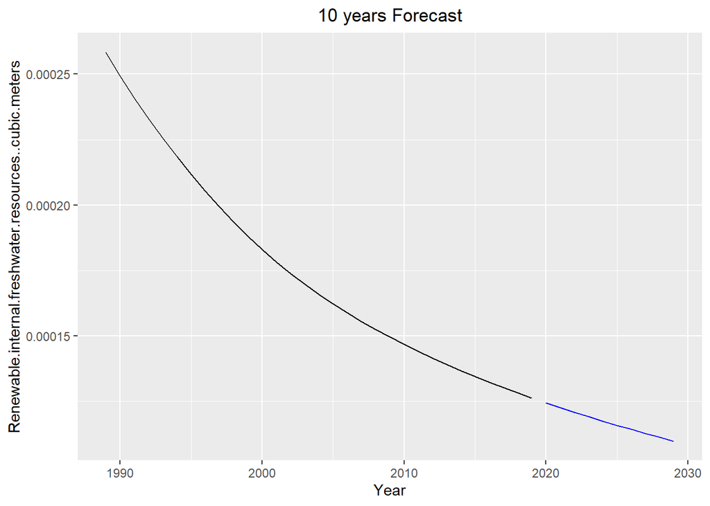

```r
ren_fresh_arima |>
  forecast(h = "10 years") |>
  autoplot(ttsibble_data, level = NULL) + labs(title = "10 years Forecast") +
  theme(plot.title = element_text(hjust = 0.5))
```

James can now say that it is forecasted a gradual decrease in “Renewable Internal Freshwater Resources” over the next 10 years, with expected values ranging from 0.0001243450 in 2020 to 0.0001098164 in 2029.

#### 0.3.0.3 Model #2

```
## Series: Renewable.internal.freshwater.resources..cubic.meters
## Model: LM w/ ARIMA(0,0,0) errors
##
## Coefficients:
##       Annual.freshwater.withdrawals..total..billion.cubic.meters.
##                                                             0e+00
## s.e.                                                        2e-04
##
## sigma^2 estimated as 4.169e-09:  log likelihood=255.6
## AIC=-507.2   AICc=-506.78   BIC=-504.34
```

James modeled the time series “Renewable.internal.freshwater.resources..cubic.meters” using an ARIMA model with an external regressor, specifically the variable “Annual.freshwater.withdrawals..total..billion.cubic.meters.” The ARIMA component of the model was specified as ARIMA(0,0,0).

James, then, proceeded to evaluate the residuals as follows to provide insights into the model’s performance.

```
## Plot variable not specified, automatically selected `.vars =
## Renewable.internal.freshwater.resources..cubic.meters`
```

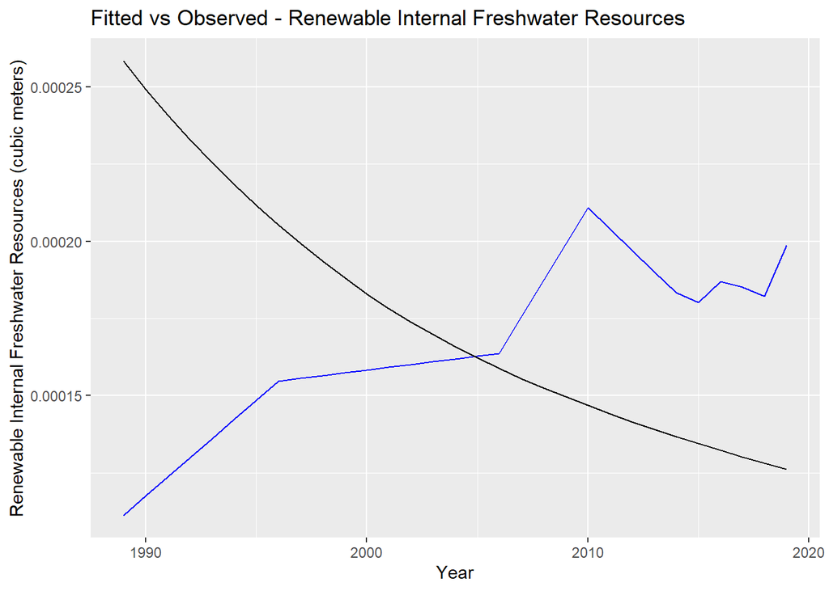

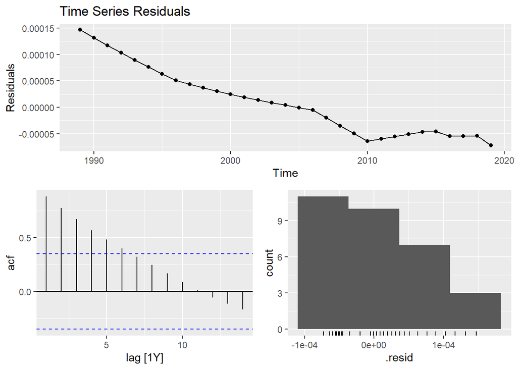

```
## # A tibble: 1 × 3
##   .model                                                       lb_stat lb_pvalue
##   <chr>                                                          <dbl>     <dbl>
## 1 "ARIMA(Renewable.internal.freshwater.resources..cubic.meter…    104.  8.88e-16
```

```
## # A tsibble: 31 x 6 [1Y]
## # Key:       .model [1]
##    .model                    Year Renewable.internal.f…¹ .fitted  .resid  .innov
##    <chr>                    <int>                  <dbl>   <dbl>   <dbl>   <dbl>
##  1 "ARIMA(Renewable.intern…  1989               0.000258 1.11e-4 1.47e-4 1.47e-4
##  2 "ARIMA(Renewable.intern…  1990               0.000249 1.17e-4 1.32e-4 1.32e-4
##  3 "ARIMA(Renewable.intern…  1991               0.000241 1.24e-4 1.17e-4 1.17e-4
##  4 "ARIMA(Renewable.intern…  1992               0.000233 1.30e-4 1.03e-4 1.03e-4
##  5 "ARIMA(Renewable.intern…  1993               0.000226 1.36e-4 8.94e-5 8.94e-5
##  6 "ARIMA(Renewable.intern…  1994               0.000218 1.42e-4 7.61e-5 7.61e-5
##  7 "ARIMA(Renewable.intern…  1995               0.000212 1.49e-4 6.32e-5 6.32e-5
##  8 "ARIMA(Renewable.intern…  1996               0.000205 1.55e-4 5.07e-5 5.07e-5
##  9 "ARIMA(Renewable.intern…  1997               0.000199 1.56e-4 4.37e-5 4.37e-5
## 10 "ARIMA(Renewable.intern…  1998               0.000194 1.56e-4 3.70e-5 3.70e-5
## # ℹ 21 more rows
## # ℹ abbreviated name: ¹Renewable.internal.freshwater.resources..cubic.meters
```

```
## # A tsibble: 10 x 6 [1Y]
## # Key:       .model [1]
##    .model     Year Renewable.internal.f…¹   .mean                          `80%`
##    <chr>     <dbl>                 <dist>   <dbl>                         <hilo>
##  1 "ARIMA(b…  2020     t(N(-177, 0.0016)) 1.24e-4 [0.0001242819, 0.0001244248]80
##  2 "ARIMA(b…  2021      t(N(-179, 0.014)) 1.23e-4 [0.0001223580, 0.0001227750]80
##  3 "ARIMA(b…  2022      t(N(-180, 0.059)) 1.21e-4 [0.0001204307, 0.0001212602]80
##  4 "ARIMA(b…  2023       t(N(-181, 0.17)) 1.19e-4 [0.0001184954, 0.0001198703]80
##  5 "ARIMA(b…  2024       t(N(-182, 0.39)) 1.18e-4 [0.0001165513, 0.0001185949]80
##  6 "ARIMA(b…  2025       t(N(-184, 0.78)) 1.16e-4 [0.0001145993, 0.0001174245]80
##  7 "ARIMA(b…  2026        t(N(-185, 1.4)) 1.14e-4 [0.0001126418, 0.0001163501]80
##  8 "ARIMA(b…  2027        t(N(-186, 2.3)) 1.13e-4 [0.0001106816, 0.0001153634]80
##  9 "ARIMA(b…  2028        t(N(-187, 3.6)) 1.12e-4 [0.0001087222, 0.0001144572]80
## 10 "ARIMA(b…  2029        t(N(-189, 5.4)) 1.10e-4 [0.0001067668, 0.0001136251]80
## # ℹ abbreviated name: ¹Renewable.internal.freshwater.resources..cubic.meters
## # ℹ 1 more variable: `95%` <hilo>
```

James generated the 10-year forecast for “Renewable Internal Freshwater Resources” using an ARIMA model. He had to use a Box-Cox transformation with a lambda value of -0.5 to stabilize variance and achieve a more normally distributed series.

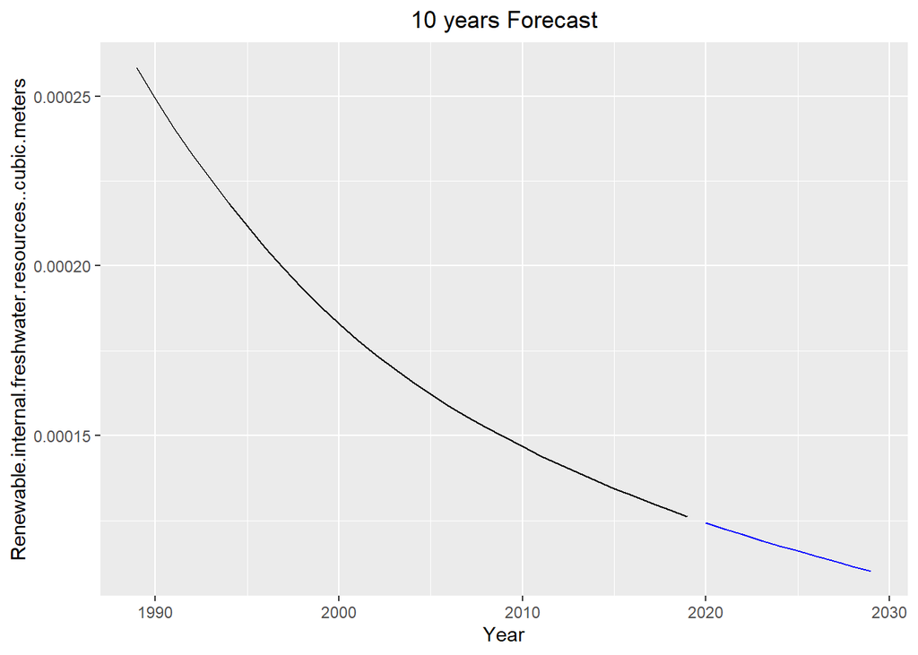

James can now say that it is forecasted a gradual decrease in “Renewable Internal Freshwater Resources” over the next 10 years, with expected values ranging from 0.0001243533 in 2020 to 0.0001101646 in 2029.

#### 0.3.0.4 Scenarios

##### 0.3.0.4.1 Cattle Scenarios

```
## [1] 215008960 221459229 228103006 234946096 241994479 249254313
```

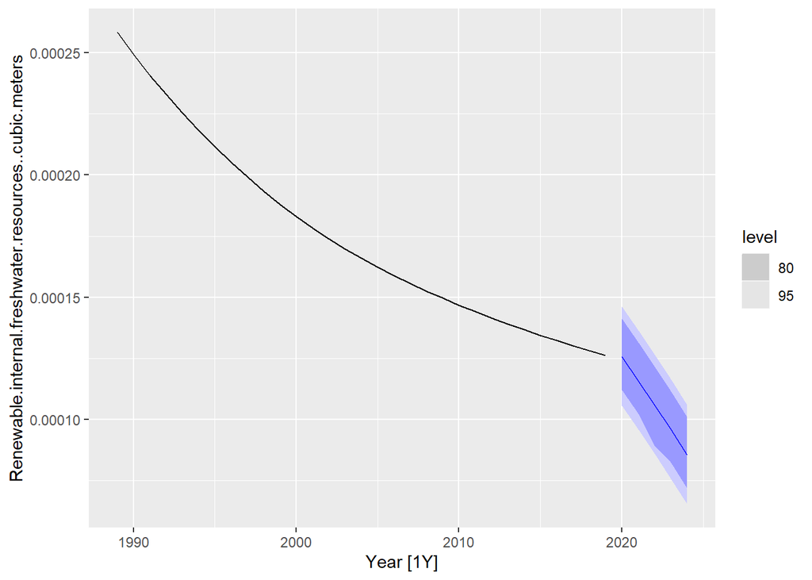

```
## # A fable: 5 x 6 [1Y]
## # Key:     Scenario, .model [1]
##   Scenario    .model  Year Renewable.internal.f…¹   .mean Cattle...00000866...…²
##   <chr>       <chr>  <dbl>                 <dist>   <dbl>                  <dbl>
## 1 StagnantCa… "ARIM…  2020           sample[5000] 1.26e-4              221459229
## 2 StagnantCa… "ARIM…  2021           sample[5000] 1.16e-4              228103006
## 3 StagnantCa… "ARIM…  2022           sample[5000] 1.06e-4              234946096
## 4 StagnantCa… "ARIM…  2023           sample[5000] 9.61e-5              241994479
## 5 StagnantCa… "ARIM…  2024           sample[5000] 8.54e-5              249254313
## # ℹ abbreviated names: ¹Renewable.internal.freshwater.resources..cubic.meters,
## #   ²Cattle...00000866....Stocks...005111....animals
```

James learns that if the cattle numbers increase by 3% every year in the future, then the renewable freshwater will decrease in a great extent.

```
## [1] 215008960 208558691 202301930 196232873 190345886 184635510
```

```
## $StagnantCattle
## # A tsibble: 5 x 2 [1Y]
##    Year Cattle...00000866....Stocks...005111....animals
##   <dbl>                                           <dbl>
## 1  2020                                       208558691
## 2  2021                                       202301930
## 3  2022                                       196232873
## 4  2023                                       190345886
## 5  2024                                       184635510
##
## attr(,"names_to")
## [1] "Scenario"
```

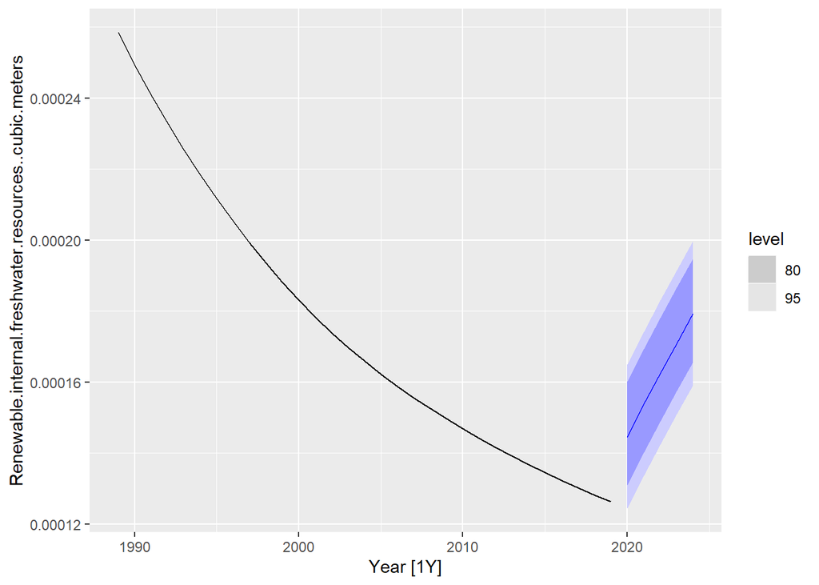

```
## # A fable: 5 x 6 [1Y]
## # Key:     Scenario, .model [1]
##   Scenario    .model  Year Renewable.internal.f…¹   .mean Cattle...00000866...…²
##   <chr>       <chr>  <dbl>                 <dist>   <dbl>                  <dbl>
## 1 StagnantCa… "ARIM…  2020           sample[5000] 1.45e-4              208558691
## 2 StagnantCa… "ARIM…  2021           sample[5000] 1.54e-4              202301930
## 3 StagnantCa… "ARIM…  2022           sample[5000] 1.62e-4              196232873
## 4 StagnantCa… "ARIM…  2023           sample[5000] 1.71e-4              190345886
## 5 StagnantCa… "ARIM…  2024           sample[5000] 1.79e-4              184635510
## # ℹ abbreviated names: ¹Renewable.internal.freshwater.resources..cubic.meters,
## #   ²Cattle...00000866....Stocks...005111....animals
```

James learns that if the cattle numbers decrease by 3% every year in the future, then the renewable freshwater will increase.

##### 0.3.0.4.2 Freshwater Withdrawals Scenarios

```
## [1] 70430000000 72542900000 74719187000 76960762610 79269585488 81647673053
```

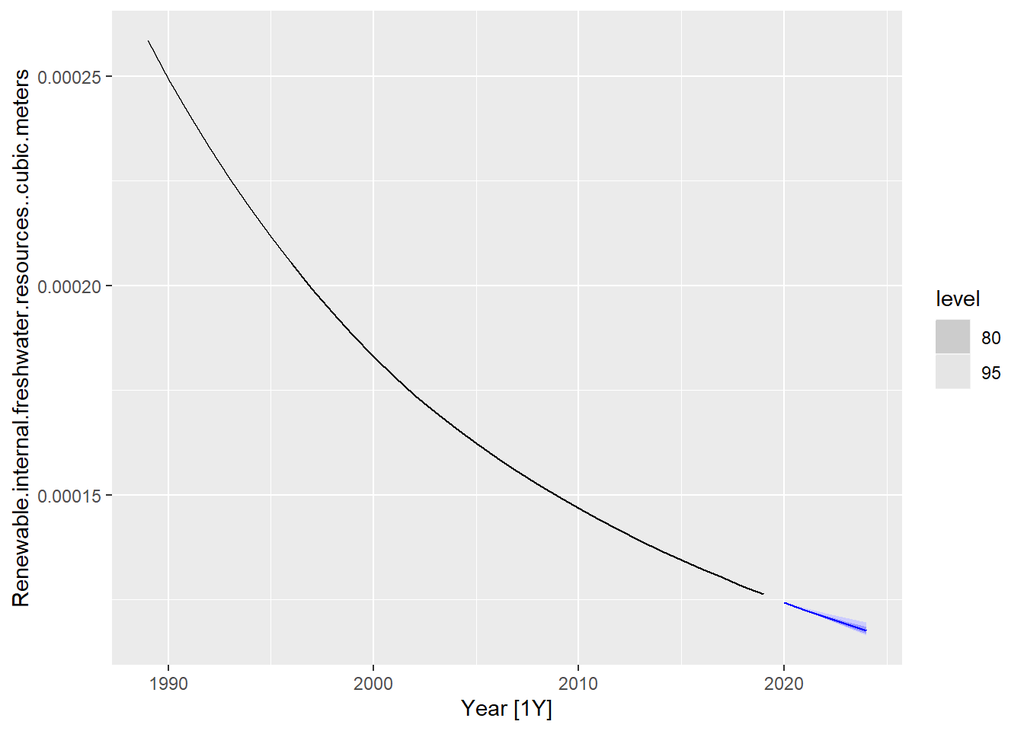

```
## # A fable: 5 x 6 [1Y]
## # Key:     Scenario, .model [1]
##   Scenario    .model  Year Renewable.internal.f…¹   .mean Annual.freshwater.wi…²
##   <chr>       <chr>  <dbl>                 <dist>   <dbl>                  <dbl>
## 1 StagnantWi… "ARIM…  2020           sample[5000] 1.24e-4            72542900000
## 2 StagnantWi… "ARIM…  2021           sample[5000] 1.23e-4            74719187000
## 3 StagnantWi… "ARIM…  2022           sample[5000] 1.21e-4            76960762610
## 4 StagnantWi… "ARIM…  2023           sample[5000] 1.19e-4            79269585488
## 5 StagnantWi… "ARIM…  2024           sample[5000] 1.18e-4            81647673053
## # ℹ abbreviated names: ¹Renewable.internal.freshwater.resources..cubic.meters,
## #   ²Annual.freshwater.withdrawals..total..billion.cubic.meters.
```

James learns that if the freshwater withdrawals increase by 3% every year in the future, then the renewable freshwater will decrease, as expected.

```
## [1] 70430000000 68317100000 66267587000 64279559390 62351172608 60480637430
```

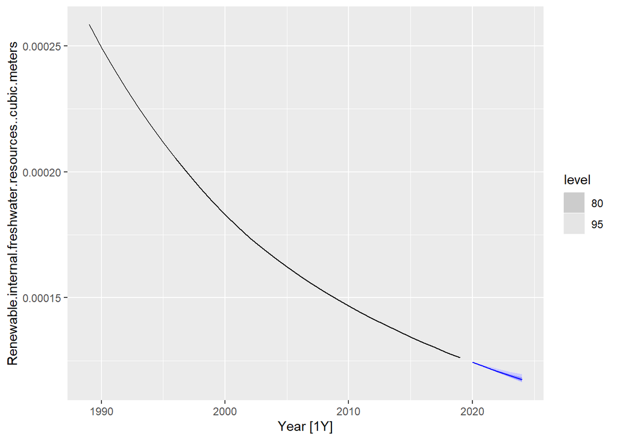

```
## # A fable: 5 x 6 [1Y]
## # Key:     Scenario, .model [1]
##   Scenario    .model  Year Renewable.internal.f…¹   .mean Annual.freshwater.wi…²
##   <chr>       <chr>  <dbl>                 <dist>   <dbl>                  <dbl>
## 1 StagnantWi… "ARIM…  2020           sample[5000] 1.24e-4            68317100000
## 2 StagnantWi… "ARIM…  2021           sample[5000] 1.23e-4            66267587000
## 3 StagnantWi… "ARIM…  2022           sample[5000] 1.21e-4            64279559390
## 4 StagnantWi… "ARIM…  2023           sample[5000] 1.19e-4            62351172608
## 5 StagnantWi… "ARIM…  2024           sample[5000] 1.18e-4            60480637430
## # ℹ abbreviated names: ¹Renewable.internal.freshwater.resources..cubic.meters,
## #   ²Annual.freshwater.withdrawals..total..billion.cubic.meters.
```

## 0.5 References:

https://ourworldindata.org/grapher/renewable-water-resources-per-capita?time=earliest..2019&country=BRA<sub>OWID_WRL</sub>USA~ARE

https://ourworldindata.org/grapher/annual-freshwater-withdrawals?tab=chart&country=OWID_WRL~BRA~USA

https://data.worldbank.org/indicator/SP.POP.TOTL?end=2019&locations=BR&start=1989&view=chart

https://ourworldindata.org/grapher/cattle-livestock-count-heads?tab=chart&country=BRA~OWID_WRL